# R Notebook

```r
library(corrplot)
library(tidyverse)
library(ggplot2)
library(maps)
library(ggmap)
library(ggplot2)
library(tmap)
library(geosphere)
library(sf)
```

```r
trips_df <- read_csv("../data/trips_data.csv")
```

#dealing with the docked_bike issue

Docked_bike types are supposed to be classic_bike types

```r
trips_df <- trips_df %>%
  mutate(rideable_type = ifelse(rideable_type == "docked_bike",
                                "classic_bike", rideable_type))
```

```r
unique(trips_df$rideable_type)
```

```
[1] "electric_bike" "classic_bike"
```

#Fixing end_lng and end_lat problems

there are 2 problems found. One being 0 values on some of the rows and another being the missing values on some of the rows. Lastly there seem to be Outliers on the histograms(This could be the 0’s but I don’t know yet.)

##dealing with the 0’s

```r
trips_df %>%
  select(everything()) %>%
  filter(end_lng == 0 | end_lat == 0)
```

| ride_id | rideable_type | started_at | ended_at | start_station_name | start_station_id | end_station_name | end_station_id | start_lat | start_lng | end_lat | end_lng | member_casual |
| --- | --- | --- | --- | --- | --- | --- | --- | --- | --- | --- | --- | --- |
| 873D50153BBC0686 | electric_bike | 2023-06-15 12:38:05 | 2023-06-15 12:38:41 | OH Charging Stx - Test | OH Charging Stx - Test | OH Charging Stx - Test | OH Charging Stx - Test | 41.86317 | -87.67981 | 0 | 0 | member |
| ADFF57D27B5BF9D2 | classic_bike | 2023-06-15 09:38:07 | 2023-06-15 09:42:57 | State St & 54th St | 646 | OH Charging Stx - Test | OH Charging Stx - Test | 41.79664 | -87.62592 | 0 | 0 | casual |
| 43107577DF9B498D | classic_bike | 2023-08-21 18:43:22 | 2023-08-21 22:05:55 | Dearborn St & Erie St | 13045 | Stony Island Ave & 63rd St | 653B | 41.89399 | -87.62932 | 0 | 0 | casual |

There are only 3 values that have 0 and in both cases this occurs on end_lng and end_lat at the same time. 2 of them are tests and one isn’t. I will convert the 0’s into an NA value and deal with it together with the other missing values.

```r
trips_df <- trips_df %>%
  mutate(end_lng = na_if(end_lng, 0),
         end_lat = na_if(end_lat, 0))
  trips_df %>%
    select(everything()) %>%
    filter(end_lat == 0 | end_lng == 0 )
```

| ride_id | rideable_type | started_at | ended_at | start_station_name | start_station_id | end_station_name | end_station_id | start_lat | start_lng | end_lat | end_lng | member_casual |
| --- | --- | --- | --- | --- | --- | --- | --- | --- | --- | --- | --- | --- |

##Cleaning Test data

I want to make sure that there are no more tests outside of the 2 I just found.

```r
trips_df %>%
  select(everything()) %>%
  filter(grepl("(Test)$", end_station_name, ignore.case=TRUE) | grepl("(Test)$", start_station_name, ignore.case=TRUE) |  grepl("(Test)$", start_station_id, ignore.case=TRUE) |  grepl("(Test)$", start_station_id, ignore.case=TRUE))
```

| ride_id | rideable_type | started_at | ended_at | start_station_name | start_station_id | end_station_name | end_station_id | start_lat | start_lng | end_lat | end_lng | member_casual |
| --- | --- | --- | --- | --- | --- | --- | --- | --- | --- | --- | --- | --- |
| 1EC494994DFD4553 | electric_bike | 2023-06-28 15:32:50 | 2023-06-28 15:33:07 | OH Charging Stx - Test | OH Charging Stx - Test | OH - BONFIRE - TESTING | 6.21.23 OLD HASTINGS | 41.86362 | -87.67967 | 41.86332 | -87.67979 | member |
| A34B8C56E7692CB5 | electric_bike | 2023-06-29 14:29:06 | 2023-06-29 14:29:13 | OH Charging Stx - Test | OH Charging Stx - Test | OH Charging Stx - Test | OH Charging Stx - Test | 41.86362 | -87.67972 | 41.86257 | -87.67994 | member |
| 465EA70E1D719562 | electric_bike | 2023-06-29 14:41:13 | 2023-06-29 14:41:19 | OH Charging Stx - Test | OH Charging Stx - Test | OH Charging Stx - Test | OH Charging Stx - Test | 41.86339 | -87.67978 | 41.86257 | -87.67994 | member |
| 89D9BB1625C66CE3 | classic_bike | 2023-06-29 14:36:06 | 2023-06-29 14:36:13 | OH Charging Stx - Test | OH Charging Stx - Test | OH Charging Stx - Test | OH Charging Stx - Test | 41.86257 | -87.67994 | 41.86257 | -87.67994 | member |
| E3AC9546FB4F0BEB | classic_bike | 2023-06-28 15:44:00 | 2023-06-28 15:44:06 | OH Charging Stx - Test | OH Charging Stx - Test | OH Charging Stx - Test | OH Charging Stx - Test | 41.86257 | -87.67994 | 41.86257 | -87.67994 | member |
| 3AA20CC3FE43F678 | classic_bike | 2023-06-28 10:56:35 | 2023-06-28 10:56:40 | OH Charging Stx - Test | OH Charging Stx - Test | OH Charging Stx - Test | OH Charging Stx - Test | 41.86257 | -87.67994 | 41.86257 | -87.67994 | member |
| 103567010777D572 | classic_bike | 2023-06-28 15:43:40 | 2023-06-28 15:43:44 | OH Charging Stx - Test | OH Charging Stx - Test | OH Charging Stx - Test | OH Charging Stx - Test | 41.86257 | -87.67994 | 41.86257 | -87.67994 | member |
| 12A36ED2AAE587FD | electric_bike | 2023-06-28 15:32:11 | 2023-06-28 15:32:27 | OH Charging Stx - Test | OH Charging Stx - Test | OH Charging Stx - Test | OH Charging Stx - Test | 41.86362 | -87.67967 | 41.86257 | -87.67994 | member |
| 0D77713ADEE7A4ED | electric_bike | 2023-06-28 15:34:27 | 2023-06-28 15:34:33 | OH Charging Stx - Test | OH Charging Stx - Test | OH Charging Stx - Test | OH Charging Stx - Test | 41.86351 | -87.67975 | 41.86257 | -87.67994 | member |
| B6A90F07CCAEEB50 | electric_bike | 2023-06-28 15:38:05 | 2023-06-28 15:38:13 | OH Charging Stx - Test | OH Charging Stx - Test | OH Charging Stx - Test | OH Charging Stx - Test | 41.86348 | -87.67987 | 41.86257 | -87.67994 | member |

[output cut: 9 more lines]

There are more. This data doesn’t serve us since they are tests.

```r
trips_df <- trips_df %>%
  select(everything()) %>%
  filter(!(grepl("(Test)$", end_station_name, ignore.case=TRUE) | grepl("(Test)$", start_station_name, ignore.case=TRUE) |  grepl("(Test)$", start_station_id, ignore.case=TRUE) |  grepl("(Test)$", start_station_id, ignore.case=TRUE)))
```

```r
trips_df %>%
  select(everything()) %>%
  filter(grepl("(Test)$", end_station_name, ignore.case=TRUE) | grepl("(Test)$", start_station_name, ignore.case=TRUE) |  grepl("(Test)$", start_station_id, ignore.case=TRUE) |  grepl("(Test)$", start_station_id, ignore.case=TRUE)) %>%
  count()
```

| n |
| --- |
| 0 |

The data is now cleaned of tests.

#Fixing the outliers

I want to now see if removing the 0’s from the data removed the outliers.

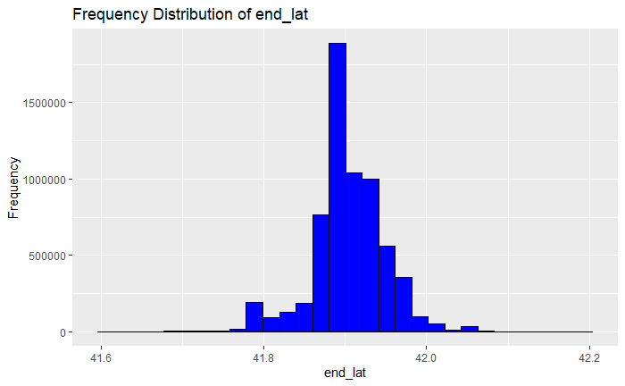

```r
ggplot(trips_df, aes(x = end_lat)) +
    geom_histogram(fill = "blue", color = "black") +
    labs(title = "Frequency Distribution of end_lat", x = "end_lat", y = "Frequency")
```

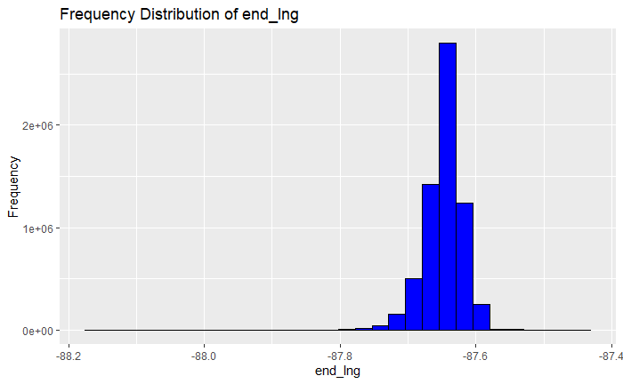

```r
ggplot(trips_df, aes(x = end_lng)) +
    geom_histogram(fill = "blue", color = "black") +
    labs(title = "Frequency Distribution of end_lng", x = "end_lng", y = "Frequency")
```

The only outliers where the 0’s so I can move on to the next step now.

#Dealing with the missing end_lng and end_lat

I know that they are both missing at the same time. Lets see if we can find a pattern. to it

```r
missing_lng_lat <- trips_df %>%
  select(everything()) %>%
  filter(!complete.cases(end_lng))

missing_lng_lat %>% count()
```

| n |
| --- |
| 8809 |

```r
missing_lng_lat %>%
  select(everything())
```

| ride_id | rideable_type | started_at | ended_at | start_station_name | start_station_id | end_station_name | end_station_id | start_lat | start_lng | end_lat | end_lng | member_casual |
| --- | --- | --- | --- | --- | --- | --- | --- | --- | --- | --- | --- | --- |
| 685DB4D7A6AF6CAE | classic_bike | 2023-06-29 17:35:41 | 2023-06-29 17:45:38 | Sedgwick St & Huron St | TA1307000062 | Halsted St & Fulton St | 23003 | 41.89467 | -87.63844 | NA | NA | casual |
| E4AB9F672ECD0966 | classic_bike | 2023-06-29 14:50:04 | 2023-06-29 15:06:49 | Wabash Ave & Grand Ave | TA1307000117 | Halsted St & Fulton St | 23003 | 41.89147 | -87.62676 | NA | NA | casual |
| B0A0B0C83B363BC3 | classic_bike | 2023-06-23 16:06:21 | 2023-06-23 16:16:55 | Cottage Grove Ave & 63rd St | KA1503000054 | Stony Island Ave & 63rd St | 653B | 41.78053 | -87.60597 | NA | NA | casual |
| D49A2A420AE05181 | classic_bike | 2023-06-30 17:08:02 | 2023-07-01 18:07:52 | Vincennes Ave & 104th St | 20124 | NA | NA | 41.70493 | -87.65687 | NA | NA | casual |
| 2C35DCA44370EAD8 | classic_bike | 2023-06-30 18:45:11 | 2023-06-30 19:06:34 | Damen Ave & Foster Ave | KA1504000149 | Lincoln Ave & Byron St | 23002 | 41.97561 | -87.67946 | NA | NA | casual |
| D19CA7CA83B28F88 | classic_bike | 2023-06-29 17:36:45 | 2023-06-29 18:02:39 | Manor Ave & Leland Ave | KA1504000127 | Lincoln Ave & Byron St | 23002 | 41.96587 | -87.70082 | NA | NA | casual |
| 1005EAF8E1C29D5C | classic_bike | 2023-06-24 13:56:09 | 2023-06-24 14:18:23 | Clark St & Bryn Mawr Ave | KA1504000151 | Lincoln Ave & Byron St | 23002 | 41.98359 | -87.66915 | NA | NA | casual |
| B34C24AD17CCB667 | classic_bike | 2023-06-22 22:32:59 | 2023-06-22 23:09:50 | Green St & Washington Blvd | 13053 | Halsted St & Fulton St | 23003 | 41.88318 | -87.64872 | NA | NA | casual |
| 64D120B77FA6F330 | classic_bike | 2023-06-22 22:32:41 | 2023-06-22 23:09:48 | Green St & Washington Blvd | 13053 | Halsted St & Fulton St | 23003 | 41.88318 | -87.64872 | NA | NA | casual |
| 92008CFA88E93F44 | classic_bike | 2023-06-22 22:33:03 | 2023-06-22 23:09:44 | Green St & Washington Blvd | 13053 | Halsted St & Fulton St | 23003 | 41.88318 | -87.64872 | NA | NA | casual |

[output cut: 990 more lines]

A lot of the data seems to also have missing end station names. I also don’t see any electric bikes on the type of bike.

Are dates related?

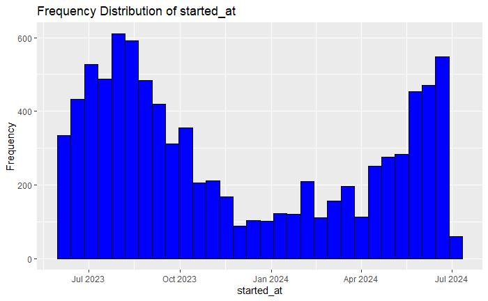

```r
ggplot(missing_lng_lat, aes(x = started_at)) +
    geom_histogram(fill = "blue", color = "black") +
    labs(title = "Frequency Distribution of started_at", x = "started_at", y = "Frequency")
```

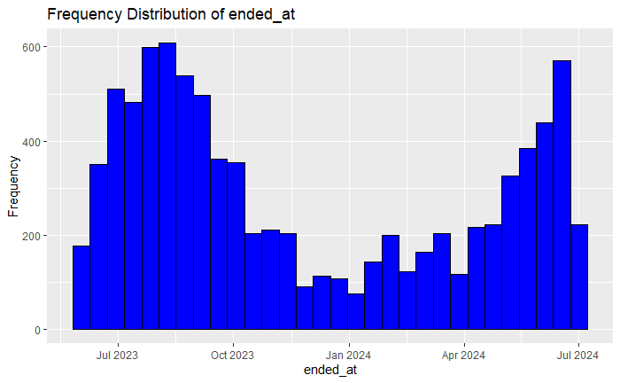

```r
ggplot(missing_lng_lat, aes(x = ended_at)) +
    geom_histogram(fill = "blue", color = "black") +
    labs(title = "Frequency Distribution of ended_at", x = "ended_at", y = "Frequency")
```

The dates have the same spread as the full dataset.

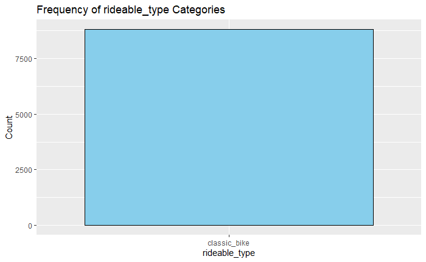

```r
ggplot(missing_lng_lat, aes(x = rideable_type)) +
    geom_bar(fill = "skyblue", color = "black") +
    labs(title = "Frequency of rideable_type Categories", x = "rideable_type", y = "Count")
```

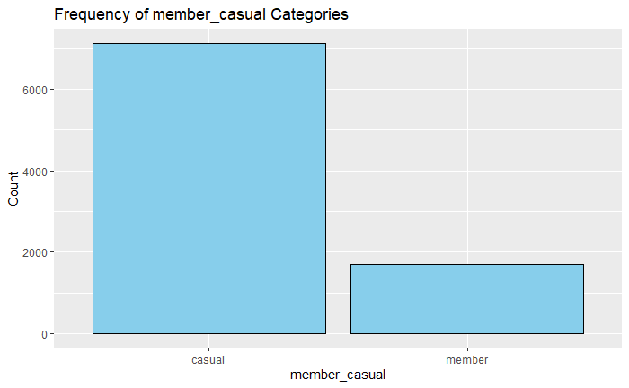

```r
ggplot(missing_lng_lat, aes(x = member_casual)) +
    geom_bar(fill = "skyblue", color = "black") +
    labs(title = "Frequency of member_casual Categories", x = "member_casual", y = "Count")
```

There are no electric bikes on the subset at all. There also are more casuals than members. This is weird because there are almost double the members on the data.

My current hypothesis is that this bikes were lost/stolen. And since the classic bikes have no tracker there would be no longitude, lattitude. couple that with the fact that there are probably more casual drivers without the gps tracker on on their phones making it the reason why there are not that many members with missnig end_lng and end_lat. since that is how those values are obtained when the driver uses a classic bike.

```r
missing_lng_lat_with_durations <- missing_lng_lat %>%
  select(everything()) %>%
  mutate(trip_duration = as.numeric(difftime(ended_at, started_at), units = "hours"))
```

```r
missing_lng_lat_with_durations %>%
  select(everything())
```

| ride_id | rideable_type | started_at | ended_at | start_station_name | start_station_id | end_station_name | end_station_id | start_lat | start_lng | end_lat | end_lng | member_casual | trip_duration |
| --- | --- | --- | --- | --- | --- | --- | --- | --- | --- | --- | --- | --- | --- |
| 685DB4D7A6AF6CAE | classic_bike | 2023-06-29 17:35:41 | 2023-06-29 17:45:38 | Sedgwick St & Huron St | TA1307000062 | Halsted St & Fulton St | 23003 | 41.89467 | -87.63844 | NA | NA | casual | 0.16583333 |
| E4AB9F672ECD0966 | classic_bike | 2023-06-29 14:50:04 | 2023-06-29 15:06:49 | Wabash Ave & Grand Ave | TA1307000117 | Halsted St & Fulton St | 23003 | 41.89147 | -87.62676 | NA | NA | casual | 0.27916667 |
| B0A0B0C83B363BC3 | classic_bike | 2023-06-23 16:06:21 | 2023-06-23 16:16:55 | Cottage Grove Ave & 63rd St | KA1503000054 | Stony Island Ave & 63rd St | 653B | 41.78053 | -87.60597 | NA | NA | casual | 0.17611111 |
| D49A2A420AE05181 | classic_bike | 2023-06-30 17:08:02 | 2023-07-01 18:07:52 | Vincennes Ave & 104th St | 20124 | NA | NA | 41.70493 | -87.65687 | NA | NA | casual | 24.99722222 |
| 2C35DCA44370EAD8 | classic_bike | 2023-06-30 18:45:11 | 2023-06-30 19:06:34 | Damen Ave & Foster Ave | KA1504000149 | Lincoln Ave & Byron St | 23002 | 41.97561 | -87.67946 | NA | NA | casual | 0.35638889 |
| D19CA7CA83B28F88 | classic_bike | 2023-06-29 17:36:45 | 2023-06-29 18:02:39 | Manor Ave & Leland Ave | KA1504000127 | Lincoln Ave & Byron St | 23002 | 41.96587 | -87.70082 | NA | NA | casual | 0.43166667 |
| 1005EAF8E1C29D5C | classic_bike | 2023-06-24 13:56:09 | 2023-06-24 14:18:23 | Clark St & Bryn Mawr Ave | KA1504000151 | Lincoln Ave & Byron St | 23002 | 41.98359 | -87.66915 | NA | NA | casual | 0.37055556 |
| B34C24AD17CCB667 | classic_bike | 2023-06-22 22:32:59 | 2023-06-22 23:09:50 | Green St & Washington Blvd | 13053 | Halsted St & Fulton St | 23003 | 41.88318 | -87.64872 | NA | NA | casual | 0.61416667 |
| 64D120B77FA6F330 | classic_bike | 2023-06-22 22:32:41 | 2023-06-22 23:09:48 | Green St & Washington Blvd | 13053 | Halsted St & Fulton St | 23003 | 41.88318 | -87.64872 | NA | NA | casual | 0.61861111 |
| 92008CFA88E93F44 | classic_bike | 2023-06-22 22:33:03 | 2023-06-22 23:09:44 | Green St & Washington Blvd | 13053 | Halsted St & Fulton St | 23003 | 41.88318 | -87.64872 | NA | NA | casual | 0.61138889 |

[output cut: 990 more lines]

```r
summary(missing_lng_lat_with_durations$trip_duration)
```

```
     Min.   1st Qu.    Median      Mean   3rd Qu.      Max.
   0.0342   24.9942   24.9978   34.8923   24.9986 1641.4844
```

```r
missing_lng_lat_with_durations %>%
  select(everything()) %>%
  filter(trip_duration < 23)
```

| ride_id | rideable_type | started_at | ended_at | start_station_name | start_station_id | end_station_name | end_station_id | start_lat | start_lng | end_lat | end_lng | member_casual | trip_duration |
| --- | --- | --- | --- | --- | --- | --- | --- | --- | --- | --- | --- | --- | --- |
| 685DB4D7A6AF6CAE | classic_bike | 2023-06-29 17:35:41 | 2023-06-29 17:45:38 | Sedgwick St & Huron St | TA1307000062 | Halsted St & Fulton St | 23003 | 41.89467 | -87.63844 | NA | NA | casual | 0.16583333 |
| E4AB9F672ECD0966 | classic_bike | 2023-06-29 14:50:04 | 2023-06-29 15:06:49 | Wabash Ave & Grand Ave | TA1307000117 | Halsted St & Fulton St | 23003 | 41.89147 | -87.62676 | NA | NA | casual | 0.27916667 |
| B0A0B0C83B363BC3 | classic_bike | 2023-06-23 16:06:21 | 2023-06-23 16:16:55 | Cottage Grove Ave & 63rd St | KA1503000054 | Stony Island Ave & 63rd St | 653B | 41.78053 | -87.60597 | NA | NA | casual | 0.17611111 |
| 2C35DCA44370EAD8 | classic_bike | 2023-06-30 18:45:11 | 2023-06-30 19:06:34 | Damen Ave & Foster Ave | KA1504000149 | Lincoln Ave & Byron St | 23002 | 41.97561 | -87.67946 | NA | NA | casual | 0.35638889 |
| D19CA7CA83B28F88 | classic_bike | 2023-06-29 17:36:45 | 2023-06-29 18:02:39 | Manor Ave & Leland Ave | KA1504000127 | Lincoln Ave & Byron St | 23002 | 41.96587 | -87.70082 | NA | NA | casual | 0.43166667 |
| 1005EAF8E1C29D5C | classic_bike | 2023-06-24 13:56:09 | 2023-06-24 14:18:23 | Clark St & Bryn Mawr Ave | KA1504000151 | Lincoln Ave & Byron St | 23002 | 41.98359 | -87.66915 | NA | NA | casual | 0.37055556 |
| B34C24AD17CCB667 | classic_bike | 2023-06-22 22:32:59 | 2023-06-22 23:09:50 | Green St & Washington Blvd | 13053 | Halsted St & Fulton St | 23003 | 41.88318 | -87.64872 | NA | NA | casual | 0.61416667 |
| 64D120B77FA6F330 | classic_bike | 2023-06-22 22:32:41 | 2023-06-22 23:09:48 | Green St & Washington Blvd | 13053 | Halsted St & Fulton St | 23003 | 41.88318 | -87.64872 | NA | NA | casual | 0.61861111 |
| 92008CFA88E93F44 | classic_bike | 2023-06-22 22:33:03 | 2023-06-22 23:09:44 | Green St & Washington Blvd | 13053 | Halsted St & Fulton St | 23003 | 41.88318 | -87.64872 | NA | NA | casual | 0.61138889 |
| 84106BA64096E4EC | classic_bike | 2023-06-30 14:06:15 | 2023-06-30 14:09:53 | Clinton St & Lake St | 13021 | Halsted St & Fulton St | 23003 | 41.88564 | -87.64182 | NA | NA | casual | 0.06055556 |

[output cut: 467 more lines]

```r
missing_lng_lat_with_durations %>%
  select(everything()) %>%
  filter(trip_duration >= 23)
```

| ride_id | rideable_type | started_at | ended_at | start_station_name | start_station_id | end_station_name | end_station_id | start_lat | start_lng | end_lat | end_lng | member_casual | trip_duration |
| --- | --- | --- | --- | --- | --- | --- | --- | --- | --- | --- | --- | --- | --- |
| D49A2A420AE05181 | classic_bike | 2023-06-30 17:08:02 | 2023-07-01 18:07:52 | Vincennes Ave & 104th St | 20124 | NA | NA | 41.70493 | -87.65687 | NA | NA | casual | 24.99722 |
| 02D5A44D96224756 | classic_bike | 2023-06-08 22:28:04 | 2023-06-09 23:27:57 | Dayton St & North Ave | 13058 | NA | NA | 41.91058 | -87.64942 | NA | NA | member | 24.99806 |
| 83A29914F1691318 | classic_bike | 2023-06-30 18:19:11 | 2023-07-01 19:18:55 | Green St & Randolph St* | chargingstx3 | NA | NA | 41.88360 | -87.64863 | NA | NA | member | 24.99556 |
| B8BCACEAFE5A25B2 | classic_bike | 2023-06-23 14:01:53 | 2023-06-24 15:01:45 | Dayton St & North Ave | 13058 | NA | NA | 41.91058 | -87.64942 | NA | NA | casual | 24.99778 |
| 2C220E5809EEAFF4 | classic_bike | 2023-06-17 15:22:41 | 2023-06-18 16:22:34 | Dayton St & North Ave | 13058 | NA | NA | 41.91058 | -87.64942 | NA | NA | casual | 24.99806 |
| E79E266999056B7C | classic_bike | 2023-06-23 15:23:32 | 2023-06-25 04:53:39 | Wells St & Concord Ln | TA1308000050 | NA | NA | 41.91213 | -87.63466 | NA | NA | casual | 37.50194 |
| 3A508060E0A3498B | classic_bike | 2023-06-04 06:24:51 | 2023-06-12 05:20:17 | Franklin St & Illinois St | RN- | NA | NA | 41.89102 | -87.63548 | NA | NA | casual | 190.92389 |
| 434701FA9456E46A | classic_bike | 2023-06-23 02:50:25 | 2023-06-24 03:50:19 | Albany Ave & 26th St | 15691 | NA | NA | 41.84448 | -87.70201 | NA | NA | casual | 24.99833 |
| DC8F171134015094 | classic_bike | 2023-06-14 22:19:26 | 2023-06-15 23:19:21 | Kedzie Ave & Harrison St | KA1504000082 | NA | NA | 41.87360 | -87.70487 | NA | NA | casual | 24.99861 |
| E4A2932EBE3AFB20 | classic_bike | 2023-06-17 13:18:16 | 2023-06-20 11:58:24 | Halsted St & Archer Ave | TA1308000013 | NA | NA | 41.84720 | -87.64679 | NA | NA | casual | 70.66889 |

[output cut: 990 more lines]

```r
NA
```

```r
missing_lng_lat_with_durations %>%
  filter(trip_duration < 23 & complete.cases(end_station_name)) %>%
  count()
```

| n |
| --- |
| 117 |

```r
missing_lng_lat_with_durations %>%
  filter(trip_duration >= 23 & complete.cases(end_station_name)) %>%
  count()
```

| n |
| --- |
| 0 |

Most of this data is greater than or equal to 24 which shows me that the great majority are lost bikes. So to clean this data I will do the following:

If the trips is longer than or equal 23 hours it will be marked as Lost/Stolen.

If the trips is shorter than 23 hours. It will be deleted. Unless the trip has an end_station_name. In which case I will use the median lng and lat of the the trips with the same station to fill out the end_lng and end_lat variables.

```r
short_trips_to_remove_list <- missing_lng_lat_with_durations %>%
  filter(trip_duration < 23 & !complete.cases(end_station_name)) %>%
  pull(ride_id)


short_trips_to_fix_list <- missing_lng_lat_with_durations %>%
  filter(trip_duration < 23 & complete.cases(end_station_name)) %>%
  pull(ride_id)

lost_bikes_list <- missing_lng_lat_with_durations %>%
  filter(trip_duration > 23) %>%
    pull(ride_id)

trips_df <- trips_df %>%
  mutate(
    end_station_name = ifelse(ride_id %in% lost_bikes_list, "Lost",end_station_name),
    end_station_id = ifelse(ride_id %in% lost_bikes_list, "Lost",end_station_id),
  )
trips_df <- trips_df %>%
  filter(!(ride_id %in% short_trips_to_remove_list))


median_df <- trips_df %>%
  group_by(end_station_name) %>%
  summarize(median_end_lng = median(end_lng, na.rm = TRUE),
            median_end_lat = median(end_lat, na.rm = TRUE)
            )


trips_df <- trips_df %>%
    left_join(median_df, by = "end_station_name") %>%
    mutate(end_lng = ifelse(!complete.cases(end_lng) | (ride_id %in% short_trips_to_fix_list), median_end_lng, end_lng),
           end_lat = ifelse(!complete.cases(end_lat) | (ride_id %in% short_trips_to_fix_list), median_end_lat, end_lat)) %>%
    select(-median_end_lng, -median_end_lat)
```

```r
trips_df %>%
  filter(!complete.cases(end_lat, end_lng) & end_station_name != "Lost") %>%
  count()
```

| n |
| --- |
| 0 |

The end_lng and end_lat will both still have Na’s But only on the trips that are marked as lost. I don’t want to mark end_lng/lat as lost since that will cause the whole column to become character type instead of a numeric type.

#mising data on names and ids

“You can either dock or lock your ebike (not both at once). Dock at any Divvy station, or use the cable to lock at any e-station or at the 500+ Divvy approved public bike racks for no additional cost. For an extra $2.40 ($1.20 for Divvy members), you can also lock to any other public bike rack, light pole, signpost, or retired parking meter within the service area.” [source](https://divvybikes.com/how-it-works/parking)

With this in mind this could be a good reason why there are so many start and end ids and names. Because some Ebikes can start and end a trip outside a station. I want to confirm this being looking at which types of bikes are missing its stations.

```r
missing_stations <- trips_df %>%
  select(everything()) %>%
  filter(!complete.cases(start_station_id,end_station_id))

missing_stations_with_duration <- missing_stations %>%
  select(everything()) %>%
  mutate(trip_duration = as.numeric(difftime(ended_at, started_at), units = "hours"))
```

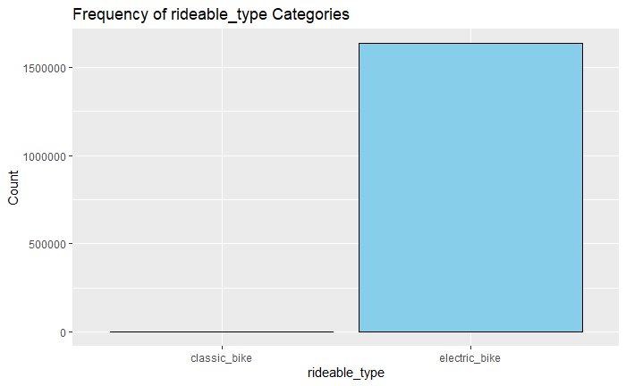

```r
ggplot(missing_stations, aes(x = rideable_type)) +
    geom_bar(fill = "skyblue", color = "black") +
    labs(title = "Frequency of rideable_type Categories", x = "rideable_type", y = "Count")
```

The great majority are electric and rarely they are 24.Now how many electric bike trips are 24 hours?

```r
missing_stations_with_duration %>%
  filter(rideable_type == "electric_bike", trip_duration > 23) %>%
  count()
```

| n |
| --- |
| 0 |

```r
missing_stations_with_duration %>%
  filter(rideable_type == "classic_bike", trip_duration > 23) %>%
  count()
```

| n |
| --- |
| 243 |

```r
trips_df <- trips_df %>%
  mutate(start_station_name = ifelse(rideable_type == "electric_bike" & is.na(start_station_id),
                                   "Out of station", start_station_name))

trips_df <- trips_df %>%
  mutate(start_station_id = ifelse(rideable_type == "electric_bike" & is.na(start_station_id),
                                   "Out of station", start_station_id))

trips_df <- trips_df %>%
  mutate(end_station_name = ifelse(rideable_type == "electric_bike" & is.na(end_station_id),
                                   "Out of station", end_station_name))

trips_df <- trips_df %>%
  mutate(end_station_id = ifelse(rideable_type == "electric_bike" & is.na(end_station_id),
                                   "Out of station", end_station_id))
```

now lets deal with the classic bikes. first the ones lasting longer than 24 hours are lost/stolen so lets fix that.

```r
trips_df <- trips_df %>%
  mutate(end_station_name = ifelse(rideable_type == "classic_bike" & is.na(end_station_id),
                                   "Lost", end_station_name))

trips_df <- trips_df %>%
  mutate(end_station_id = ifelse(rideable_type == "classic_bike" & is.na(end_station_id),
                                   "Lost", end_station_id))
```

```r
trips_df %>%
  filter(!complete.cases(.) & end_station_id != "Lost")
```

| ride_id | rideable_type | started_at | ended_at | start_station_name | start_station_id | end_station_name | end_station_id | start_lat | start_lng | end_lat | end_lng | member_casual |
| --- | --- | --- | --- | --- | --- | --- | --- | --- | --- | --- | --- | --- |
| 9D6A7C67EFB688FD | classic_bike | 2023-10-28 15:29:02 | 2023-10-28 15:40:51 | NA | NA | Morgan St & Lake St* | chargingstx4 | 41.87 | -87.69 | 41.88549 | -87.65229 | member |
| 62F2649E24950EED | classic_bike | 2023-10-28 22:02:07 | 2023-10-28 22:16:04 | NA | NA | LaSalle St & Washington St | 13006 | 41.89 | -87.65 | 41.88266 | -87.63253 | casual |
| 5685FB0E8547AD9E | classic_bike | 2023-10-27 16:14:14 | 2023-10-27 16:27:02 | NA | NA | Halsted St & Clybourn Ave | 331 | 41.88 | -87.64 | 41.90967 | -87.64813 | member |
| A4F8B87B8F8DB9FE | classic_bike | 2023-10-27 16:23:25 | 2023-10-27 16:30:47 | NA | NA | Leavitt St & Armitage Ave | TA1309000029 | 41.92 | -87.71 | 41.91781 | -87.68244 | casual |
| 938CB5BE37B0378E | classic_bike | 2023-11-05 09:00:18 | 2023-11-05 09:10:07 | NA | NA | Peoria St & Jackson Blvd | 13158 | 41.89 | -87.63 | 41.87764 | -87.64962 | member |
| 66661D737DFC2B72 | classic_bike | 2023-11-05 12:06:15 | 2023-11-05 12:15:12 | NA | NA | Lakeview Ave & Fullerton Pkwy | TA1309000019 | 41.94 | -87.65 | 41.92586 | -87.63897 | casual |

Because its only 6 rows of data and I don’t know the reason why the stations are missing I will remove this rows.

```r
trips_df <- trips_df %>%
  filter(complete.cases(.) | end_station_id == "Lost")
```

```r
trips_df %>%
  select(everything()) %>%
  filter(!complete.cases(.) & end_station_id != "Lost") %>%
  count()
```

| n |
| --- |
| 0 |

this section is done.

#lattitude and longitude low accuracy.

There are inconsistencies with decimal points on the latitude and longitude the decimal values go form 2 decimal places to up to 13. I would need at least 4 to have a somewhat accurate analysis since bellow 4 there is an error of 1.11 km. Which is more than enough to have more than one station at the same location. This canno’t be changed but I will abstain myself from checking the distance between beginning and end.

#Creating a new variable.

```r
trips_df %>%
  select(everything())
```

| ride_id | rideable_type | started_at | ended_at | start_station_name | start_station_id | end_station_name | end_station_id | start_lat | start_lng | end_lat | end_lng | member_casual |
| --- | --- | --- | --- | --- | --- | --- | --- | --- | --- | --- | --- | --- |
| 6F1682AC40EB6F71 | electric_bike | 2023-06-05 13:34:12 | 2023-06-05 14:31:56 | Out of station | Out of station | Out of station | Out of station | 41.91000 | -87.69000 | 41.91000 | -87.70000 | member |
| 622A1686D64948EB | electric_bike | 2023-06-05 01:30:22 | 2023-06-05 01:33:06 | Out of station | Out of station | Out of station | Out of station | 41.94000 | -87.65000 | 41.94000 | -87.65000 | member |
| 3C88859D926253B4 | electric_bike | 2023-06-20 18:15:49 | 2023-06-20 18:32:05 | Out of station | Out of station | Out of station | Out of station | 41.95000 | -87.68000 | 41.92000 | -87.63000 | member |
| EAD8A5E0259DEC88 | electric_bike | 2023-06-19 14:56:00 | 2023-06-19 15:00:35 | Out of station | Out of station | Out of station | Out of station | 41.99000 | -87.65000 | 41.98000 | -87.66000 | member |
| 5A36F21930D6A55C | electric_bike | 2023-06-19 15:03:34 | 2023-06-19 15:07:16 | Out of station | Out of station | Out of station | Out of station | 41.98000 | -87.66000 | 41.99000 | -87.65000 | member |
| CF682EA7D0F961DB | electric_bike | 2023-06-09 21:30:25 | 2023-06-09 21:49:52 | Out of station | Out of station | Out of station | Out of station | 41.99000 | -87.68000 | 41.94000 | -87.65000 | member |
| 4910FBB710157754 | electric_bike | 2023-06-03 13:34:09 | 2023-06-03 13:34:28 | Out of station | Out of station | Out of station | Out of station | 41.88000 | -87.62000 | 41.88000 | -87.62000 | member |
| EA19D850A42F56D8 | electric_bike | 2023-06-03 13:34:46 | 2023-06-03 13:35:00 | Out of station | Out of station | Out of station | Out of station | 41.88000 | -87.62000 | 41.88000 | -87.62000 | member |
| E68F43784662A2D0 | electric_bike | 2023-06-02 22:27:35 | 2023-06-02 22:35:26 | Out of station | Out of station | Out of station | Out of station | 41.95000 | -87.64000 | 41.95000 | -87.65000 | member |
| 5A013E29CC001611 | electric_bike | 2023-06-02 21:18:31 | 2023-06-03 01:27:19 | Out of station | Out of station | Out of station | Out of station | 41.87000 | -87.63000 | 41.89000 | -87.63000 | member |

[output cut: 990 more lines]

I will need to new columns for the analysis trip_duration.

```r
trips_df <- trips_df %>%
  select(everything()) %>%
  mutate(trip_duration = as.numeric(difftime(ended_at, started_at), units = "mins"))
```

```r
summary(trips_df$trip_duration)
```

```
     Min.   1st Qu.    Median      Mean   3rd Qu.      Max.
-16656.52      5.60      9.83     18.47     17.45  98489.07
```

Lets see how all of this problems look.

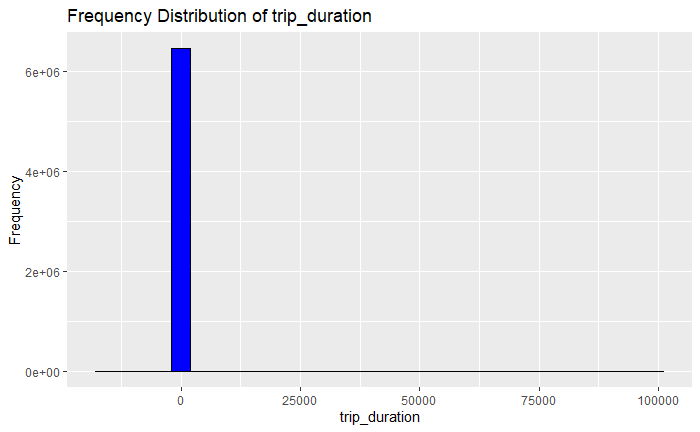

```r
ggplot(trips_df, aes(x = trip_duration)) +
    geom_histogram(fill = "blue", color = "black") +
    labs(title = "Frequency Distribution of trip_duration", x = "trip_duration", y = "Frequency")
```

I want to first explore the negative times. Which should not be possible.

```r
trips_df %>% count()
```

| n |
| --- |
| 6453614 |

```r
negative_trips <- trips_df %>%
  select(everything()) %>%
  filter(trip_duration <= 0)
```

This data encompasses 0.0006% of the total

Next lets check the trip duration that are longer than 24 hours since this should not be possible.

```r
Long_trips <- trips_df %>%
  select(everything()) %>%
  filter(trip_duration > 1440 & end_station_name != "Lost")
```

This encompasses 0.0008% of the data.

This trips should not be possible, and due to them together en composing 0.001% of the data. I will delete them to avoid it from affecting the analysis.

```r
trips_df <- trips_df %>%
  select(everything()) %>%
  filter(!(trip_duration > 1440 & end_station_name != "Lost"))

trips_df <- trips_df %>%
  select(everything()) %>%
  filter(trip_duration > 0)
```

#creating categorical columns

rideable_type and member_casual, start_station_name, start_station_id, end_station_name, end_station_id are all categorical variables on the data set. I transform them into factors on the code bellow.

```r
trips_df$rideable_type <- as.factor(trips_df$rideable_type)
class(trips_df$rideable_type)
```

```
[1] "factor"
```

```r
trips_df$member_casual <- as.factor(trips_df$member_casual)
class(trips_df$rideable_type)
```

```
[1] "factor"
```

```r
trips_df$start_station_id <- as.factor(trips_df$start_station_id)
class(trips_df$start_station_id)
```

```
[1] "factor"
```

```r
trips_df$start_station_name <- as.factor(trips_df$start_station_name)
class(trips_df$start_station_name)
```

```
[1] "factor"
```

```r
trips_df$end_station_name <- as.factor(trips_df$end_station_name)
class(trips_df$end_station_name)
```

```
[1] "factor"
```

```r
trips_df$end_station_id <- as.factor(trips_df$end_station_id)
class(trips_df$end_station_id)
```

```
[1] "factor"
```

With this I conclude the cleaning.

```r
write.csv(trips_df, "../data/trips_data_cleaned.csv", row.names = FALSE)
```